# Homework 1 PSTAT 131

Robert Miller

2022-09-29

#1 Supervised learning is where you give the training data with the output data.For example, you are teaching a child what a dog is by pointing at a dog and saying this is a dog. Unsupervised learning is where the machine is given training data but output data. The machine must figure out the output what it thinks the output data is on its own.

#2 In the context of machine learning, A regression model is where your output data is quantitative (output is a number). In a classification model your output data is qualitative(is or isn’t something).

#3 Two common regression metrics for machine learning is Training Mean Squared Error and Test Mean Squared Error. For Classification metrics two common metrics are Training Error rate and Test Error rate.

#4 Descriptive models are ones that can visually explain data, as stated in the lecture “using a line on a scatterplot.” Predictive models are ones that can predict the output y with with minimum reducible error. Inferential models are used to test relationship between the outcome and predictors.

#5 A mechanistic model assumes that data must fit a parametric form, but the data wont match the true function. An empirically-driven model on the other hand makes no assumptions about the underlying function. Both models can suffer from overfitting. Mechanistic models can made more flexible by adding parameters while empirically-driven models are more flexible as they make no assumptions.

A mechanistic model is easier to understand because the data is being fit to a function rather then not.

Bias-Variance tradeoff is where you can either have a simple model(closely related to mechanistic) that has high bias but low variance. A flexible model(such as an empirically-driven) will have low bias but will have high variance.

#6 voting in favor of a candidate is an example of a predictive model. You are trying to predict a voting outcome based on voter data.

change in support of a candidate based on personal contact is an example of an inferential model. There is a hypothesis that personal contact will have an effect on voting outcome and looks to see if that is true(whether the outcome was positive or negative).

Exploratory data analysis #1

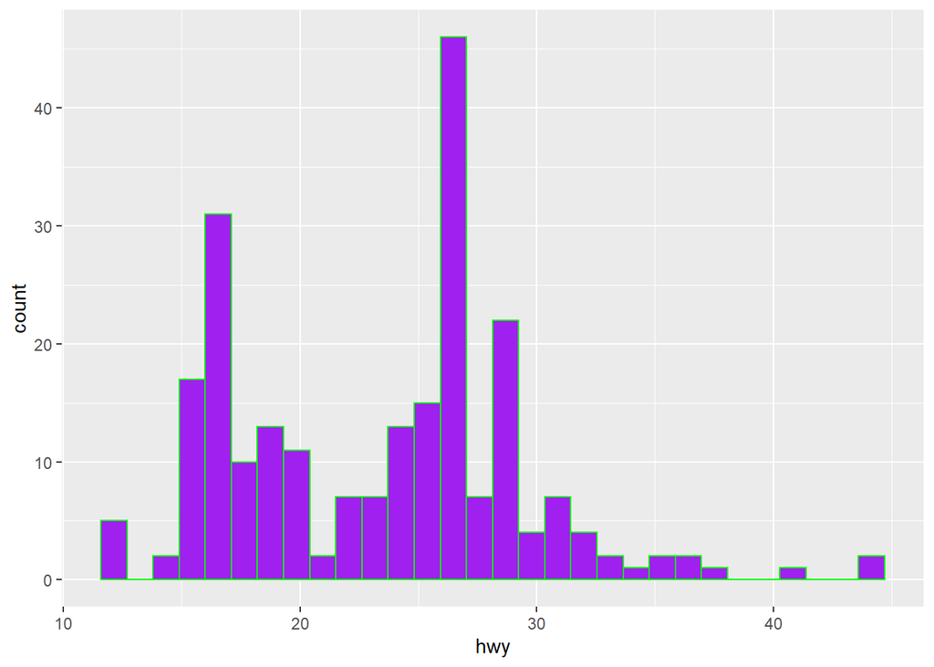

```r
#creates a histogram of highway mpg
ph<- ggplot(data = mpg, aes(x=hwy))+geom_histogram(col="green",fill="purple")
ph
```

#2

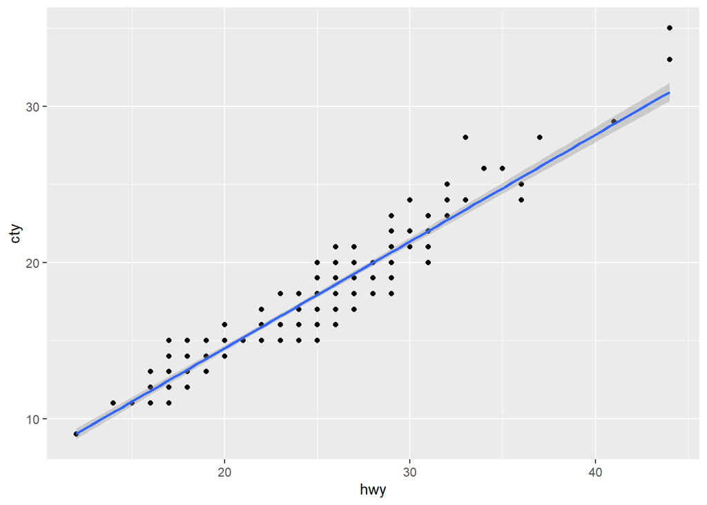

```r
#creates a linear model between city and highway mpg
HWYvCity <- lm(mpg$cty ~mpg$hwy)
#Scatterplot of city vs hwy mpg
ps<- ggplot(data = mpg, aes(x=hwy,y=cty))+geom_point()+geom_smooth(method=lm)
ps
```